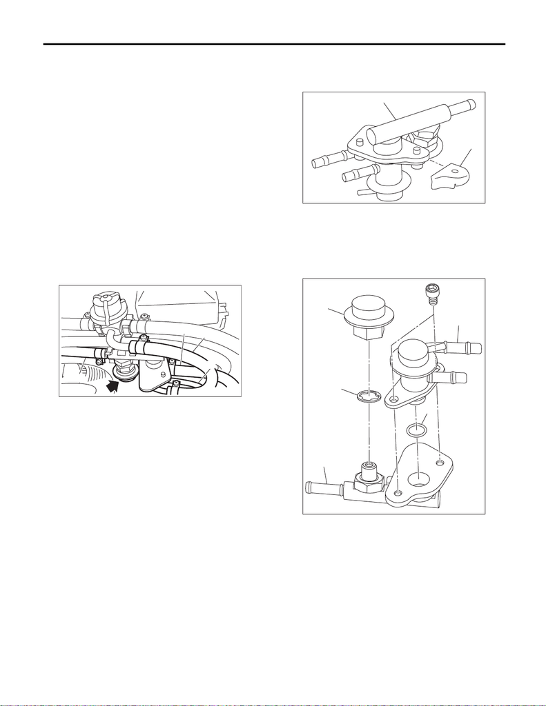

Pressure Regulator & Damper Assembly

FUEL INJECTION (FUEL SYSTEMS)

34.Pressure Regulator & Damp-

er Assembly

A: REMOVAL

WARNING:

Place “NO OPEN FLAMES” signs near the

working area.

CAUTION:

• Be careful not to spill fuel.

• Catch the fuel from hoses using a container

or cloth.

1) Release the fuel pressure. <Ref. to FU(STI)-64,

RELEASING OF FUEL PRESSURE, PROCE-

DURE, Fuel.>

2) Disconnect the vacuum hose (A) from the pres-

sure regulator and damper assembly.

3) Disconnect the fuel return hose (B) and fuel

hose (C) from the pressure regulator & damper as-

sembly, and remove the fuel regulator & damper

assembly.

B: INSTALLATION

Install in the reverse order of removal.

NOTE:

For the information about connecting the fuel return

hose and fuel hose, refer to “Fuel Delivery, Return

and Evaporation Lines”. <Ref. to FU(STI)-99,

CONNECTING FUEL DELIVERY HOSE, FUEL

RETURN HOSE AND FUEL HOSE, INSTALLA-

TION, Fuel Delivery, Return and Evaporation

Lines.>

C: DISASSEMBLY

1) Remove the fuel pipe protector from the pres-

sure regulator and damper assembly.

2) Remove the pulsation damper and fuel pipe gas-

ket from the fuel holder assembly, and remove the

pressure regulator from the fuel holder assembly.

FU-08483

(A)

(C)

(B)

(B)

(A) Pressure regulator & damper ASSY

(B) Fuel pipe protector

(A) Fuel holder ASSY

(B) Pulsation damper

(C) Fuel pipe gasket

(D) Pressure regulator

(E) O-ring

FU-06745

(A)

(B)

(C)

(B)

(A)

(D)

(E)

FU-06746

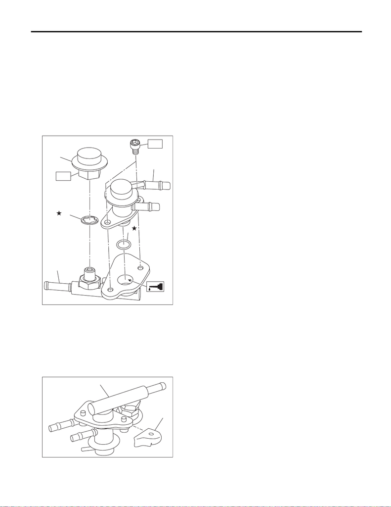

D: ASSEMBLY

1) Install the pressure regulator to the fuel holder

assembly, and install the fuel pipe gasket and pul-

sation damper to the fuel holder assembly.

NOTE:

• Use new O-rings and fuel pipe gaskets.

• Apply a thin coat of engine oil to the pressure

regulator installation hole of fuel holder assembly.

Tightening torque:

T1: 6.4 N·m (0.7 kgf-m, 4.7 ft-lb)

T2: 21.6 N·m (2.2 kgf-m, 15.9 ft-lb)

2) Install the fuel pipe protector to the pressure reg-

ulator and damper assembly.

E: INSPECTION

1) Check that the pressure regulator and damper

assembly has no deformation, cracks or other dam-

ages.

2) Check that the vacuum hose, fuel return hose

and fuel hose have no cracks, damage or loose

part.

(A) Fuel holder ASSY

(B) Pulsation damper

(C) Fuel pipe gasket

(D) Pressure regulator

(E) O-ring

(A) Pressure regulator & damper ASSY

(B) Fuel pipe protector

(C)

(B)

(A)

(D)

(E)

T1

T2

FU-06747

FU-06745

(A)

(B)